# PA1_template.Rmd

DSRocky

24 10 2017

# Overview

This is the report addressing the questions of Assignment 1 in the Data Science Specialization Course “Reproducible Research”. The report will include the instructions for: 1. Loading and preprocessing the data 2. Calculating the mean total number of steps taken per day 3. Describing the daily activity pattern 4. Imputing missing values 5. Analyzing differences in activity patterns between weekdays and weekends.

## 1. Loading and preprocessing the data

The data file is taken from the following repository on Github: https://github.com/rdpeng/RepData_PeerAssessment1

### Prerequisites

I forked the repository on Github, the data file “activity.zip” is included there and thus did not need to be downloaded separately. I have unzipped the data and copied it into my workspace in RStudio, in order to work with it.

### Loading the data

Loading the data into RStudio.

```r
read.csv("activity.csv")
```

[output not shown]

Storing the data into a variable to be able to handle it more convienentely.

```r
activity <- read.csv("activity.csv")
```

## 2. Calculating the mean total number of steps taken per day

For this part of the assignment, missing values can be ignored (as per instruction). Create new variable steps, which contains the total steps taken per day.

```r
stepsdate <- tapply(activity$steps, activity$date, sum)
```

Create a histogram of the total number of steps taken each day.

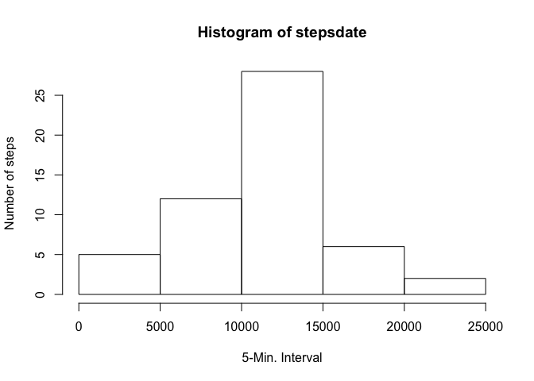

```r
hist(stepsdate, xlab="5-Min. Interval", ylab="Number of steps")
```

Calculate the mean of steps taken per day.

```r
mean(stepsdate, na.rm=TRUE)
```

```
## [1] 10766.19
```

Calculate the median of steps taken per day.

```r
median(stepsdate, na.rm=TRUE)
```

```
## [1] 10765
```

## 3. Describing the daily activity pattern

Make a time series plot (i.e. type = “l”) of the 5-minute interval (x-axis) and the average number of steps taken, averaged across all days (y-axis).

Calculate average, storing it in the variable avgstepsint.

```r
avgstepsint <- tapply(activity$steps, activity$interval, mean, na.rm=TRUE)
```

Plotting the graphic

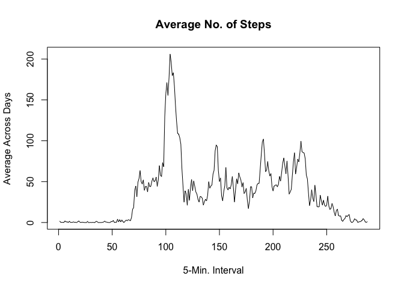

```r
plot(avgstepsint, type="l", main="Average No. of Steps", ylab = "Average Across Days", xlab="5-Min. Interval")
```

Which 5-minute interval, on average across all the days in the dataset, contains the maximum number of steps?

```r
maxInt <- which.max(avgstepsint)
print(maxInt)
```

```
## 835
## 104
```

## 4. Imputing missing values

Note that there are a number of days/intervals where there are missing values (coded as NA). The presence of missing days may introduce bias into some calculations or summaries of the data.

Calculate and report the total number of missing values in the dataset (i.e. the total number of rows with NAs)

```r
sum(is.na(activity))
```

```
## [1] 2304
```

Devise a strategy for filling in all of the missing values in the dataset. The strategy does not need to be sophisticated. For example, you could use the mean/median for that day, or the mean for that 5-minute interval, etc.

For this part - we will take the interval mean.

Create a new dataset that is equal to the original dataset but with the missing data filled in.

```r
newdata <- activity
for (i in 1:length(newdata[,1])){
     if(is.na(newdata[i,1])==TRUE){
         newdata[i,1]= avgstepsint[i]
   }}
```

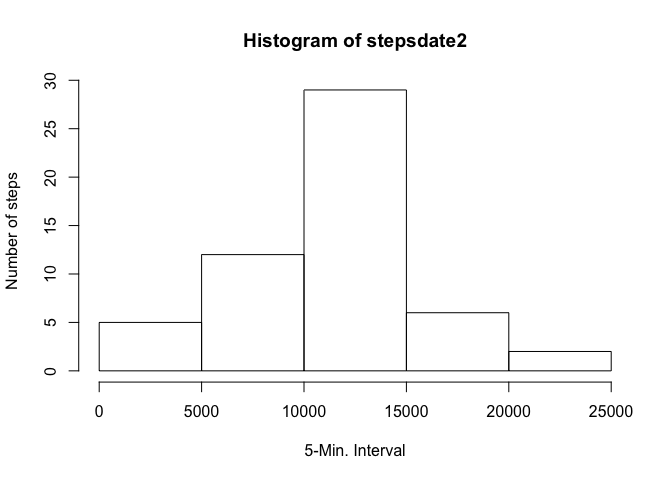

```r
stepsdate2 <- tapply(newdata$steps, newdata$date, sum)
hist(stepsdate2, xlab="5-Min. Interval", ylab="Number of steps")
```

```r
mean(stepsdate2, na.rm=TRUE)
```

```
## [1] 10766.19
```

```r
median(stepsdate2, na.rm=TRUE)
```

```
## [1] 10765.59
```

## 5. Analyzing differences in activity patterns between weekdays and weekends.

For this part the weekdays() function may be of some help here. Use the dataset with the filled-in missing values for this part.

Creating a new variable in the newdata. This will show us the day of the week.

```r
newdata$weekday <- weekdays(as.Date(newdata$date))
```

Create a new factor variable in the dataset with two levels – “weekday” and “weekend” indicating whether a given date is a weekday or weekend day.

```r
newdata$daytype <- ifelse(newdata$weekday == "Samstag" | newdata$weekday =="Sonntag", "weekend", "weekday")
```

Make a panel plot containing a time series plot (i.e. type = “l”) of the 5-minute interval (x-axis) and the average number of steps taken, averaged across all weekday days or weekend days (y-axis). See the README file in the GitHub repository to see an example of what this plot should look like using simulated data.

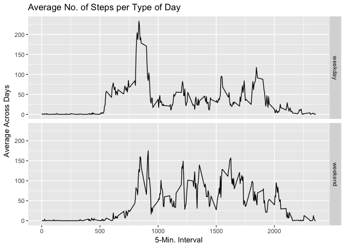

```r
library(ggplot2)
avgsteps2 <- aggregate(steps~interval + daytype, data=newdata, mean)
ggplot(avgsteps2, aes(interval, steps)) + geom_line() + facet_grid(daytype ~ . ) + xlab("5-Min. Interval") + ylab("Average Across Days") + ggtitle("Average No. of Steps per Type of Day")
```